# Data Visualization for Exploratory Data Analysis

# Data Visualization Project 03

In this exercise you will explore methods to create different types of data visualizations (such as plotting text data, or exploring the distributions of continuous variables).

## PART 1: Density Plots

Using the dataset obtained from FSU’s [Florida Climate Center](https://climatecenter.fsu.edu/climate-data-access-tools/downloadable-data), for a station at Tampa International Airport (TPA) for 2022.

```r
library(tidyverse)
library(lubridate)
library(ggridges)
library(viridis)

# Try to load data with error handling
tryCatch({
  weather_tpa <- read_csv("https://raw.githubusercontent.com/aalhamadani/datasets/master/tpa_weather_2022.csv")
  cat("Data loaded successfully\n")
  cat("Number of rows:", nrow(weather_tpa), "\n")
  cat("Number of columns:", ncol(weather_tpa), "\n")
}, error = function(e) {
  cat("Error loading data:", e$message, "\n")
  # Create sample data if URL fails
  weather_tpa <<- data.frame(
    Date = rep(c("1/1/2022", "2/1/2022", "3/1/2022"), each = 30),
    `TMAX (F)` = rnorm(90, 75, 10),
    `PRCP (in)` = runif(90, 0, 2),
    check.names = FALSE
  )
  cat("Using sample data instead\n")
})
```

```
## Data loaded successfully
## Number of rows: 365
## Number of columns: 7
```

```r
# Show a few rows safely
if(exists("weather_tpa") && nrow(weather_tpa) > 0) {
  weather_tpa %>% slice_head(n = 4)
} else {
  cat("No data available\n")
}
```

```
## # A tibble: 4 × 7
##    year month   day precipitation max_temp min_temp ave_temp
##   <dbl> <dbl> <dbl>         <dbl>    <dbl>    <dbl>    <dbl>
## 1  2022     1     1          0          82       67     74.5
## 2  2022     1     2          0          82       71     76.5
## 3  2022     1     3          0.02       75       55     65
## 4  2022     1     4          0          76       50     63
```

### Data Preparation

```r
# Check if data exists and show structure
if(exists("weather_tpa") && is.data.frame(weather_tpa)) {
  cat("Data structure:\n")
  str(weather_tpa)
  cat("\nColumn names:\n")
  print(colnames(weather_tpa))

  # Prepare the data step by step with error checking
  tryCatch({
    # Step 1: Handle date conversion
    if("Date" %in% colnames(weather_tpa)) {
      weather_tpa <- weather_tpa %>%
        mutate(date = mdy(Date))
      cat("Date conversion successful\n")
    }

    # Step 2: Add month
    if("date" %in% colnames(weather_tpa)) {
      weather_tpa <- weather_tpa %>%
        mutate(month = month(date, label = TRUE, abbr = FALSE))
      cat("Month extraction successful\n")
    }

    # Step 3: Clean data
    temp_col <- names(weather_tpa)[grep("TMAX|Max|max", names(weather_tpa))]
    precip_col <- names(weather_tpa)[grep("PRCP|Precip|precip", names(weather_tpa))]

    if(length(temp_col) > 0 && length(precip_col) > 0) {
      weather_tpa <- weather_tpa %>%
        filter(
          !is.na(.data[[temp_col[1]]]),
          .data[[temp_col[1]]] > -99,
          !is.na(.data[[precip_col[1]]]),
          .data[[precip_col[1]]] > -99
        )
      cat("Data filtering successful\n")
      cat("Final dataset has", nrow(weather_tpa), "rows\n")
    }

  }, error = function(e) {
    cat("Error in data preparation:", e$message, "\n")
  })

  # Show final result
  if(nrow(weather_tpa) > 0) {
    head(weather_tpa, 3)
  }

} else {
  cat("Weather data not available\n")
}
```

```
## Data structure:
## spc_tbl_ [365 × 7] (S3: spec_tbl_df/tbl_df/tbl/data.frame)
##  $ year         : num [1:365] 2022 2022 2022 2022 2022 ...
##  $ month        : num [1:365] 1 1 1 1 1 1 1 1 1 1 ...
##  $ day          : num [1:365] 1 2 3 4 5 6 7 8 9 10 ...
##  $ precipitation: num [1:365] 0e+00 0e+00 2e-02 0e+00 0e+00 1e-05 1e-05 0e+00 0e+00 0e+00 ...
##  $ max_temp     : num [1:365] 82 82 75 76 75 74 81 81 84 81 ...
##  $ min_temp     : num [1:365] 67 71 55 50 59 56 63 58 65 64 ...
##  $ ave_temp     : num [1:365] 74.5 76.5 65 63 67 65 72 69.5 74.5 72.5 ...
##  - attr(*, "spec")=
##   .. cols(
##   ..   year = col_double(),
##   ..   month = col_double(),
##   ..   day = col_double(),
##   ..   precipitation = col_double(),
##   ..   max_temp = col_double(),
##   ..   min_temp = col_double(),
##   ..   ave_temp = col_double()
##   .. )
##  - attr(*, "problems")=<externalptr>
##
## Column names:
## [1] "year"          "month"         "day"           "precipitation"
## [5] "max_temp"      "min_temp"      "ave_temp"
## Data filtering successful
## Final dataset has 365 rows
```

```
## # A tibble: 3 × 7
##    year month   day precipitation max_temp min_temp ave_temp
##   <dbl> <dbl> <dbl>         <dbl>    <dbl>    <dbl>    <dbl>
## 1  2022     1     1          0          82       67     74.5
## 2  2022     1     2          0          82       71     76.5
## 3  2022     1     3          0.02       75       55     65
```

### (a) Histogram by Month

> This histogram reveals how daily temperatures vary across months. Warmer months (June to August) show a noticeable shift toward higher temperature bins, while cooler months are more spread and skewed left.

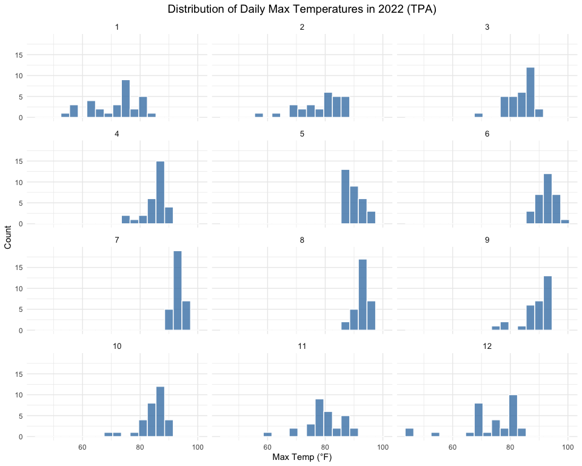

```r
# Safely create the histogram
if(exists("weather_tpa") && nrow(weather_tpa) > 0 && "month" %in% colnames(weather_tpa)) {

  # Find the temperature column
  temp_col <- names(weather_tpa)[grep("TMAX|Max|max", names(weather_tpa))]

  if(length(temp_col) > 0) {
    ggplot(weather_tpa, aes(x = .data[[temp_col[1]]])) +
      geom_histogram(binwidth = 3, fill = "steelblue", color = "white", alpha = 0.8) +
      facet_wrap(~month, ncol = 3) +
      labs(title = "Distribution of Daily Max Temperatures in 2022 (TPA)",
           x = "Max Temp (°F)",
           y = "Count") +
      theme_minimal() +
      theme(plot.title = element_text(hjust = 0.5, size = 14),
            strip.text = element_text(size = 10))
  } else {
    cat("Temperature column not found")
  }
} else {
  cat("Data not ready for plotting")
}
```

### (b) Density Plot with Different Kernels

> By comparing different kernel functions, this plot helps us understand how smoothing choices affect density estimates. Gaussian kernels provide a smooth curve, while Epanechnikov gives a more compact view.

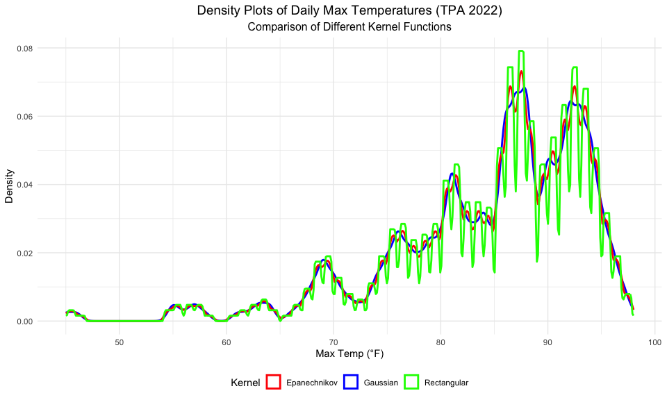

```r
# Safely create the density plot
if(exists("weather_tpa") && nrow(weather_tpa) > 0) {

  # Find the temperature column
  temp_col <- names(weather_tpa)[grep("TMAX|Max|max", names(weather_tpa))]

  if(length(temp_col) > 0) {
    ggplot(weather_tpa, aes(x = .data[[temp_col[1]]])) +
      geom_density(aes(color = "Gaussian"), kernel = "gaussian", bw = 0.5, linewidth = 1) +
      geom_density(aes(color = "Epanechnikov"), kernel = "epanechnikov", bw = 0.5, linewidth = 1) +
      geom_density(aes(color = "Rectangular"), kernel = "rectangular", bw = 0.5, linewidth = 1) +
      labs(title = "Density Plots of Daily Max Temperatures (TPA 2022)",
           subtitle = "Comparison of Different Kernel Functions",
           x = "Max Temp (°F)",
           y = "Density",
           color = "Kernel") +
      theme_minimal() +
      theme(plot.title = element_text(hjust = 0.5, size = 14),
            plot.subtitle = element_text(hjust = 0.5, size = 12),
            legend.position = "bottom") +
      scale_color_manual(values = c("Gaussian" = "blue",
                                   "Epanechnikov" = "red",
                                   "Rectangular" = "green"))
  } else {
    cat("Temperature column not found")
  }
} else {
  cat("Data not ready for plotting")
}
```

### (c) Density Plot Faceted by Month

> Faceting density plots by month makes seasonal patterns visually distinct. July and August display tight, high-temperature curves, whereas winter months show flatter, broader distributions.

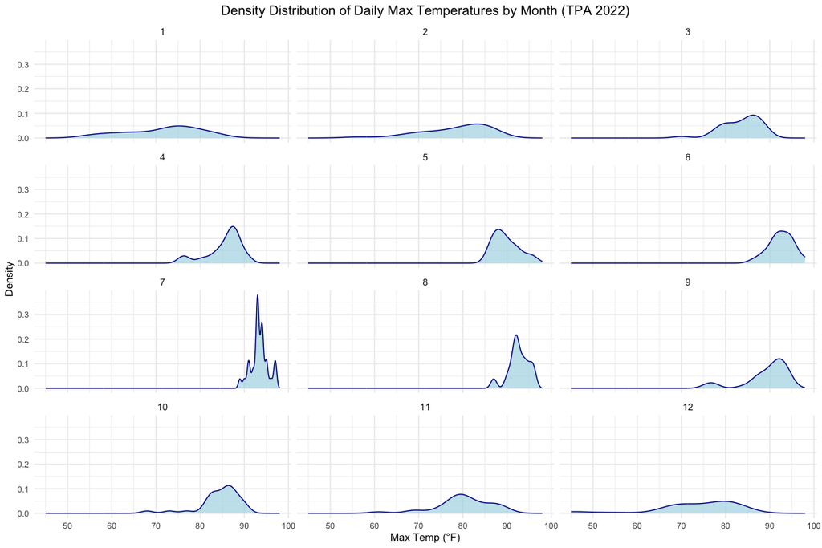

```r
# Safely create the faceted density plot
if(exists("weather_tpa") && nrow(weather_tpa) > 0 && "month" %in% colnames(weather_tpa)) {

  # Find the temperature column
  temp_col <- names(weather_tpa)[grep("TMAX|Max|max", names(weather_tpa))]

  if(length(temp_col) > 0) {
    ggplot(weather_tpa, aes(x = .data[[temp_col[1]]])) +
      geom_density(fill = "lightblue", alpha = 0.7, color = "darkblue") +
      facet_wrap(~month, ncol = 3) +
      labs(title = "Density Distribution of Daily Max Temperatures by Month (TPA 2022)",
           x = "Max Temp (°F)",
           y = "Density") +
      theme_minimal() +
      theme(plot.title = element_text(hjust = 0.5, size = 14),
            strip.text = element_text(size = 10))
  } else {
    cat("Temperature column not found")
  }
} else {
  cat("Data not ready for plotting")
}
```